# Pertemuan 2 - Regresi

## Penangan Autokorelasi dengan Metode Hildreth-Lu

```r
#Hildreth-Lu
hildreth.lu.func<- function(r, model){
  x1 <- model.matrix(model)[,2]
  x2 <- model.matrix(model)[,3]
  x3 <- model.matrix(model)[,4]

  y <- model.response(model.frame(model))
  n <- length(y)
  t <- 2:n

  y <- y[t]-r*y[t-1]
  x1 <- x1[t]-r*x1[t-1]
  x2 <- x2[t]-r*x2[t-1]
  x3 <- x3[t]-r*x3[t-1]

  return(lm(y~x1+x2+x3))
}

#Pencarian rho yang meminimumkan SSE
r <- c(seq(0.1,0.9, by= 0.1))
tab <- data.frame("rho" = r, "SSE" = sapply(r, function(i){deviance(hildreth.lu.func(i, model))}))
round(tab, 4)
```

```
##   rho      SSE
## 1 0.1 344250.2
## 2 0.2 292105.9
## 3 0.3 246724.0
## 4 0.4 208158.0
## 5 0.5 176540.8
## 6 0.6 152130.3
## 7 0.7 135333.5
## 8 0.8 126645.3
## 9 0.9 126491.2
```

Berdasarkan iterasi rho dari rentang 0.1 sampai 0.9 dengan looping sebesar 0.1 didapatkan rho teroptimum adalah rho = 0.9 dengan nilai SSE terkecil. Namun, hasil tersebut masih kurang teliti sehingga akan dicari kembali rho yang lebih optimum dengan ketelitian yang lebih. Supaya rho yang didapatkan lebih teliti selanjutnya dilakukan iterasi kembali dari selang 0.8 sampai 0.9 dengan looping sebesar 0.001

```r
#Rho optimal di sekitar 0.4
rOpt <- seq(0.8,0.9, by= 0.001)
tabOpt <- data.frame("rho" = rOpt, "SSE" = sapply(rOpt, function(i){deviance(hildreth.lu.func(i, model))}))
head(tabOpt[order(tabOpt$SSE),])
```

```
##      rho      SSE
## 53 0.852 125480.8
## 52 0.851 125481.2
## 54 0.853 125481.4
## 51 0.850 125482.4
## 55 0.854 125482.8
## 50 0.849 125484.4
```

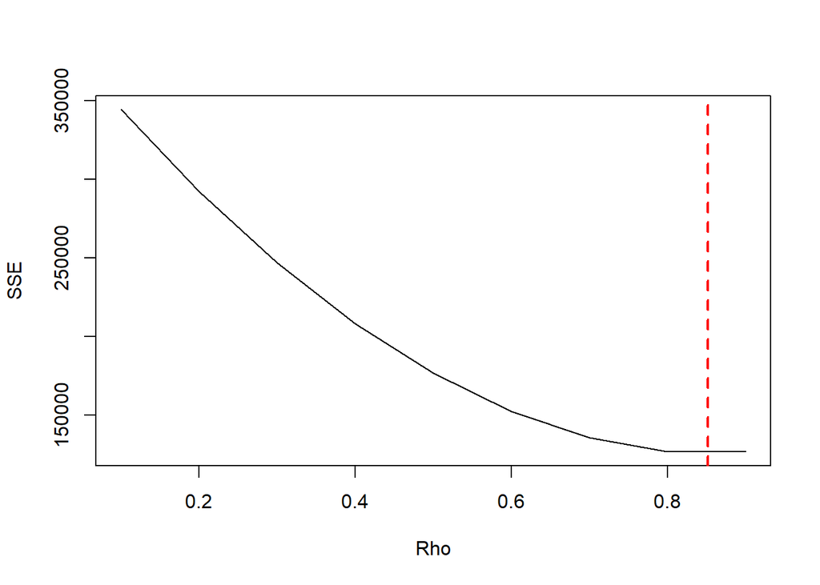

```r
#Grafik SSE optimum
par(mfrow = c(1,1))
plot(tab$SSE ~ tab$rho , type = "l", xlab = "Rho", ylab = "SSE")
abline(v = tabOpt[tabOpt$SSE==min(tabOpt$SSE),"rho"], lty = 2, col="red",lwd=2)
text(x=0.852, y=0.2397500, labels = "rho=0.341", cex = 0.8)
```

Perhitungan yang dilakukan menunjukkan bahwa nilai rho optimum, yaitu saat SSE terkecil terdapat pada nilai $ρ=0.852$. Hal tersebut juga ditunjukkan pada plot SSE Optimum. Selanjutnya, model didapatkan dengan mengevaluasi nilai rho ke dalam fungsi `hildreth.lu.func`, serta dilanjutkan dengan pengujian autokorelasi dengan uji Durbin-Watson. Namun, setelah pengecekan tersebut tidak lupa koefisien regresi tersebut digunakan untuk transformasi balik. Persamaan hasil transformasi itulah yang menjadi persamaan sesungguhnya.

```r
#Model terbaik
model_HL <- hildreth.lu.func(0.852, model)
summary(model_HL)
```

```
##
## Call:
## lm(formula = y ~ x1 + x2 + x3)
##
## Residuals:
##    Min     1Q Median     3Q    Max
## -95.36 -26.86 -10.89  18.20 194.62
##
## Coefficients:
##               Estimate Std. Error t value Pr(>|t|)
## (Intercept) -5.582e+03  2.320e+03  -2.406   0.0214 *
## x1           1.917e+01  7.852e+00   2.441   0.0197 *
## x2          -9.782e-03  1.369e-02  -0.714   0.4796
## x3          -4.008e-04  1.156e-03  -0.347   0.7309
## ---
## Signif. codes:  0 '***' 0.001 '**' 0.01 '*' 0.05 '.' 0.1 ' ' 1
##
## Residual standard error: 59.04 on 36 degrees of freedom
## Multiple R-squared:  0.1538, Adjusted R-squared:  0.08329
## F-statistic: 2.181 on 3 and 36 DF,  p-value: 0.1071
```

```r
#Transformasi Balik
cat("y = ", coef(model_HL)[1]/(1-0.852), "+", coef(model_HL)[2],"x1","+", coef(model_HL)[3],"x2","+", coef(model_HL)[4],"x3", sep = "")
```

```
## y = -37714.19+19.1659x1+-0.00978165x2+-0.0004007806x3
```

```r
#Deteksi autokorelasi
dwtest(model_HL)
```

```
##
##  Durbin-Watson test
##
## data:  model_HL
## DW = 1.426, p-value = 0.02525
## alternative hypothesis: true autocorrelation is greater than 0
```

Setelah dilakukan tranformasi balik, didapatkan model dengan metode Hildreth-Lu sebagai berikut.
$$y_i=-37714.19+19.1659x_t-0.00978165x2-0.0004007806x3$$
Hasil uji Durbin-Watson menunjukkan bahwa nilai DW sebesar $1.426$ yang masih kurang dari nilai DU sehingga masih terdapat autokorelasi. Hal ini juga dinyatakan oleh nilai p-value < alpha 5%.

## Perbandingan Nilai SSE dari Ketiga Metode

```r
#Perbandingan
sse_Modelawal <- anova(model)$`Sum Sq`[-c(1,2,3)]
sse_ModelCO <- anova(CO_manual)$`Sum Sq`[-c(1,2,3)]
sse_ModelHL <- anova(model_HL)$`Sum Sq`[-c(1,2,3)]
mse_Modelawal <- sse_Modelawal/length(data$Harga)
mse_ModelCO <- sse_ModelCO/length(data$Harga)
mse_ModelHL <- sse_ModelHL/length(data$Harga)
akurasi <- matrix(c(sse_Modelawal,sse_ModelCO,sse_ModelHL,
                    mse_Modelawal,mse_ModelCO,mse_ModelHL),nrow=2,ncol=3,byrow = T)
colnames(akurasi) <- c("Model Awal", "Model Cochrane-Orcutt", "Model Hildreth-Lu")
row.names(akurasi) <- c("SSE","MSE")
akurasi
```

```
##     Model Awal Model Cochrane-Orcutt Model Hildreth-Lu
## SSE 403335.477            125480.836        125480.843
## MSE   9837.451              3060.508          3060.508
```

```r
kable(akurasi)
```

|  | Model Awal | Model Cochrane-Orcutt | Model Hildreth-Lu |
| --- | --- | --- | --- |
| SSE | 403335.477 | 125480.836 | 125480.843 |
| MSE | 9837.451 | 3060.508 | 3060.508 |

Hasil penanganan autokorelasi dengan metode Cochrane-Orcutt dan Hildreth-Lu memiliki SSE yang tidak jauh berbeda, pada metode Hildreth-Lu dan lebih baik dibandingkan model awal sebesar $403335.477$. Namun, autokorelasi tetap terjadi dan tidak tertangani oleh kedua metode ini.

## Pemanggilan *Packages*

```r
library(forecast)
library(graphics)
library(TTR)
library(TSA)
library(rio)
library(ggplot2)
library(lmtest)
library(orcutt)
library(HoRM)
library(corrplot)
library(RColorBrewer)
library(scales)
library(dplyr)
library(knitr)
```

## Input Data

```r
data <- import("https://raw.githubusercontent.com/dewidesis/MPDW-Prak/main/Pertemuan%202/data_wine.csv")
View(data)

flip <- function(data){
  new <- data[rev(rownames(data)),]
  rownames(new) <- NULL
  new
}

data <- flip(data)
View(data)
```

## Eksplorasi Data

Sebelum melakukan regresi, akan diperlihatkan *plot time-series*.

```r
# Eksplorasi Data
summary(data)
```

```
##      Tahun          Panen          Produksi          Harga
##  Min.   :1980   Min.   :  501   Min.   :  4307   Min.   :211.0
##  1st Qu.:1990   1st Qu.: 1374   1st Qu.:  9664   1st Qu.:362.0
##  Median :2000   Median : 8704   Median : 60739   Median :560.6
##  Mean   :2000   Mean   : 7646   Mean   : 53633   Mean   :536.6
##  3rd Qu.:2010   3rd Qu.:12002   3rd Qu.: 84853   3rd Qu.:692.7
##  Max.   :2020   Max.   :19200   Max.   :150000   Max.   :865.4
```

```r
# Membuat Matriks Korelasi
matriks <- cor(data)
matriks
```

```
##              Tahun     Panen  Produksi     Harga
## Tahun    1.0000000 0.9663489 0.9560102 0.8521437
## Panen    0.9663489 1.0000000 0.9898948 0.8345795
## Produksi 0.9560102 0.9898948 1.0000000 0.8108177
## Harga    0.8521437 0.8345795 0.8108177 1.0000000
```

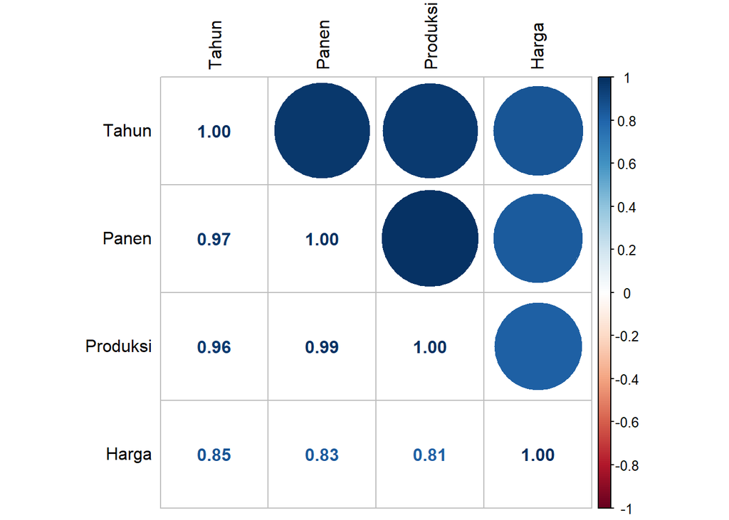

```r
corrplot.mixed(matriks, upper = 'circle', lower = 'number', order = "original",
               tl.col="black", tl.pos = "lt",diag = 'l',
               number.digits=2, number.cex=1)
```

Matriks korelasi di atas menunjukkan hubungan positif yang kuat antar semua peubah penjelas dengan peubah respon. Peubah respon : Harga Peubah penjelas : Tahun, Panen, Produksi

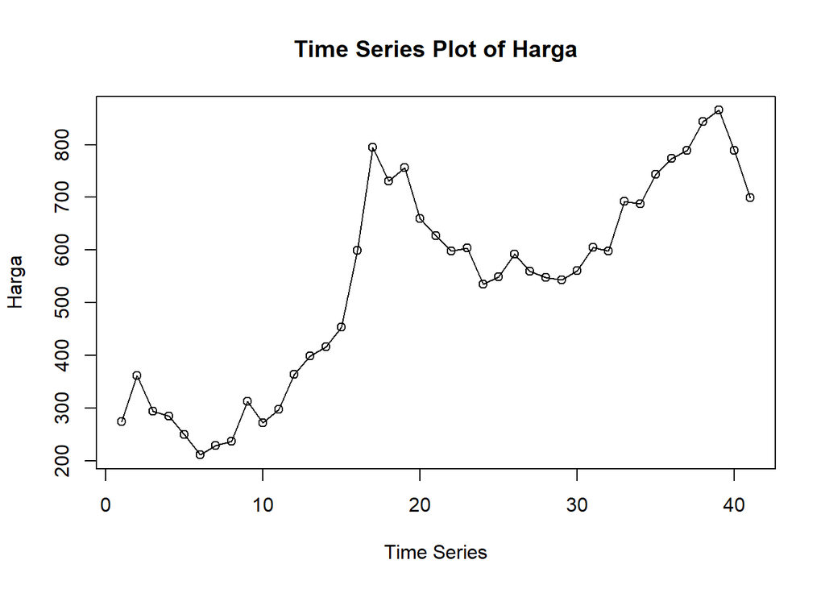

```r
#Membuat Objek Time Series
data.ts <- ts(data$Harga)

#Plot Time Series
ts.plot(data.ts, xlab = "Time Series",
        ylab = "Harga",
        main = "Time Series Plot of Harga")
points(data.ts)
```

Dapat dilihat pada time series plot di atas bahwa data tersebut berpola tren.

## Regresi

```r
#Pembuatan Model Regresi
#Model Regresi
model <- lm(Harga~Tahun+Panen+Produksi, data=data)
summary(model)
```

```
##
## Call:
## lm(formula = Harga ~ Tahun + Panen + Produksi, data = data)
##
## Residuals:
##     Min      1Q  Median      3Q     Max
## -136.54  -84.19  -12.62   34.30  286.14
##
## Coefficients:
##               Estimate Std. Error t value Pr(>|t|)
## (Intercept) -2.195e+04  1.063e+04  -2.064   0.0461 *
## Tahun        1.122e+01  5.358e+00   2.093   0.0432 *
## Panen        3.139e-02  2.331e-02   1.347   0.1863
## Produksi    -3.525e-03  2.810e-03  -1.254   0.2176
## ---
## Signif. codes:  0 '***' 0.001 '**' 0.01 '*' 0.05 '.' 0.1 ' ' 1
##
## Residual standard error: 104.4 on 37 degrees of freedom
## Multiple R-squared:  0.7391, Adjusted R-squared:  0.718
## F-statistic: 34.94 on 3 and 37 DF,  p-value: 6.878e-11
```

```r
#Melakukan uji terhadap sisaan
#Sisaan dan Fitted Value
sisaan <- residuals(model)
fittedvalue <- predict(model)
```

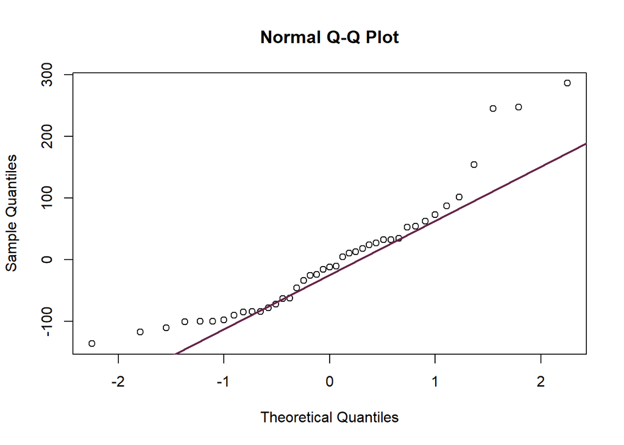

```r
#Diagnostik dengan Eksploratif
qqnorm(sisaan)

#Normal Q-Q Plot
qqline(sisaan, col = "#662549", lwd = 2)
```

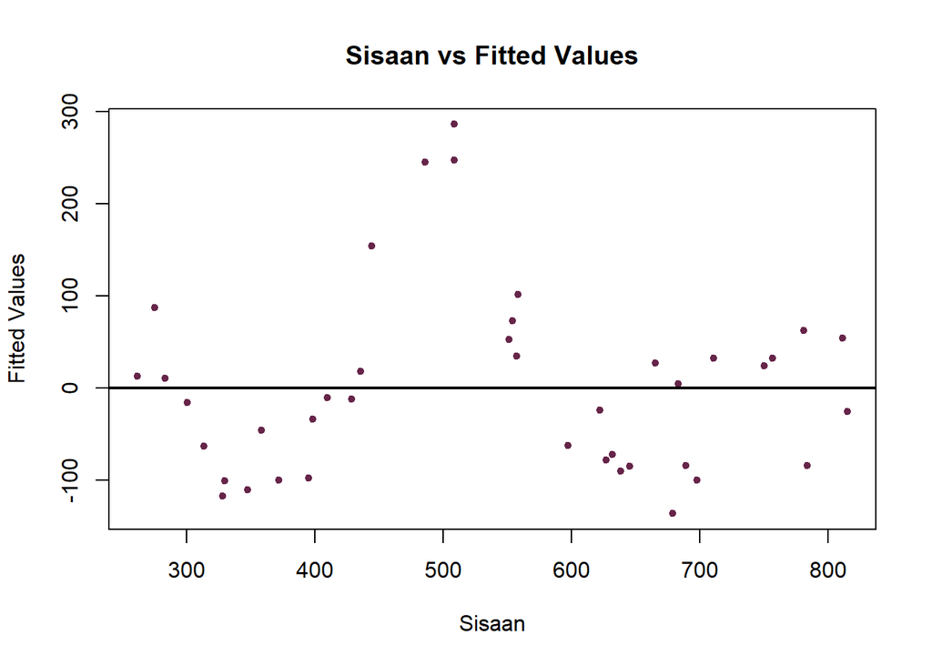

```r
plot(fittedvalue, sisaan, col = "#662549", pch = 20, xlab = "Sisaan", ylab = "Fitted Values", main = "Sisaan vs Fitted Values")
abline(a = 0, b = 0, lwd = 2)
```

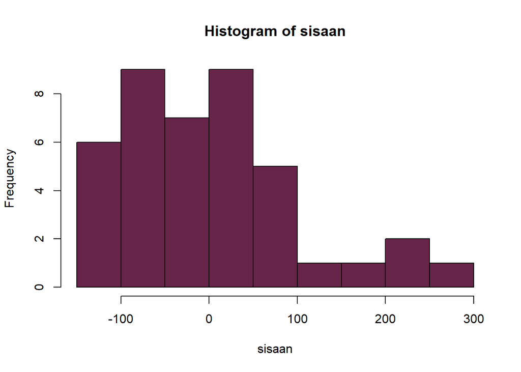

```r
#Histogram Sisaan
hist(sisaan, col = "#662549")
```

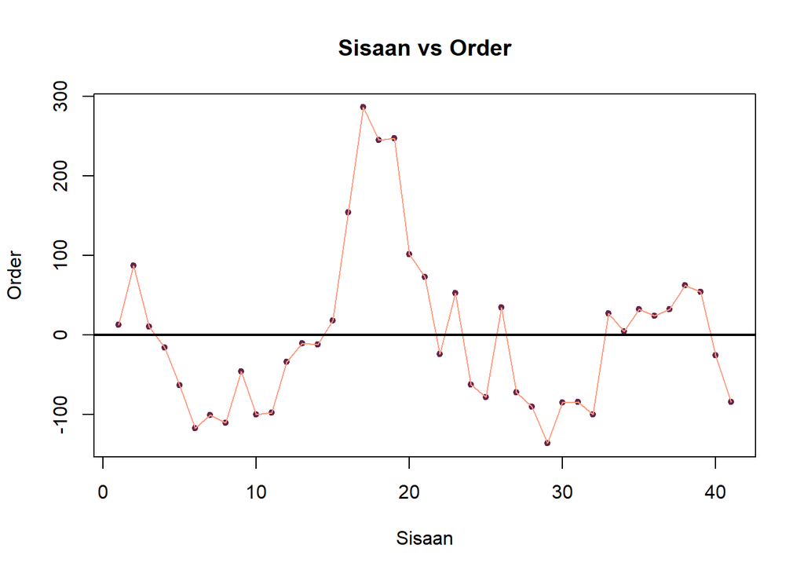

```r
plot(seq(1,41,1), sisaan, col = "#662549", pch = 20, xlab = "Sisaan", ylab = "Order", main = "Sisaan vs Order")

lines(seq(1,41,1), sisaan, col = "#FF9B82")
abline(a = 0, b = 0, lwd = 2)
```

Berdasarkan hasil Normal Q-Q Plot menunjukkan bahwa sisaan cenderung menyebar normal. Berdasarkan histogram sisaan terlihat bahwa sisaan menyebar ke kanan (positive skewness). Berdasarkan Plot sisaan vs Order, terlihat bahwa sisaan terdapat pola naik turun. Hal tersebut menunjukkan adanya autokorelasi karena ada pola antar sisaan.

## Uji Formal Normality Test

H0 : sisaan mengikuti sebaran normal H1 : Sisaan tidak mengikuti sebaran normal

```r
ks.test(sisaan, "pnorm", mean=mean(sisaan), sd=sd(sisaan))
```

```
##
##  Exact one-sample Kolmogorov-Smirnov test
##
## data:  sisaan
## D = 0.12241, p-value = 0.5306
## alternative hypothesis: two-sided
```

Berdasarkan tes normalitas menggunakan Kolmogrov-Smirnov Test didapatkan
$$p value > \alpha$$
5% yang artinya sisaan menyebar normal (terima H0).

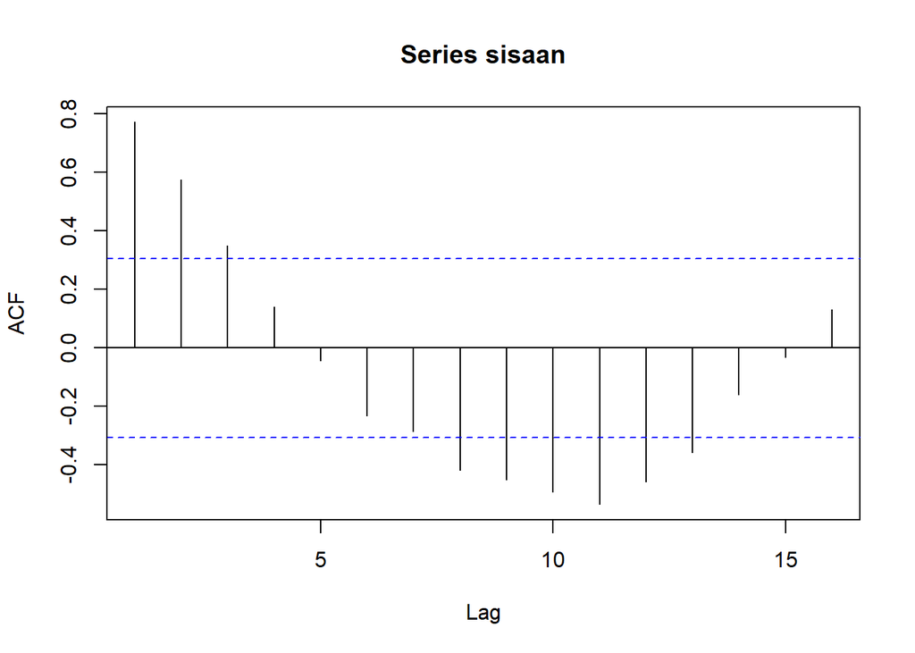

```r
#ACF dan PACF identifikasi autokorelasi
acf(sisaan)
```

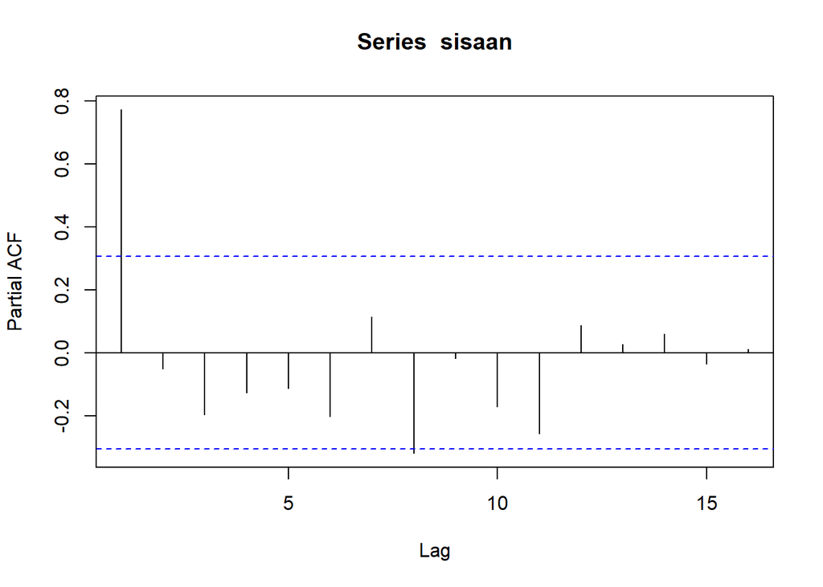

```r
pacf(sisaan)
```

Menurut Plot ACF dan PACF, terlihat bahwa terdapat garis melewati batas selang. Artinya, terdapat autokorelasi dalam model.